# Big Data

## Data Visualization in Different Graphs

**Output**: HTML Notebook

**Font Family**: Times **Font Size**: 12pt **Line Spacing**: 1.05

**Team Members**: **Group 13**

- **Pranava Sree Pottipati**
- **Sana Reddy Gaddam**
- **Harshaanjaneyavarma Samanthapudi**
- **Vijaya Raghava Ponnaganti**
- **Ravi Chandra Polavarapu**
- **Rishik Pendurthi**

## I. Installing Libraries and Loading the Data

### a. Libraries Used in the Project

The required libraries are imported in the code cell below. Here’s an explanation of each library:

- **pandas**: A powerful data manipulation and analysis library for Python, providing data structures like DataFrames that are ideal for handling tabular data, similar to R’s `tidyverse`.
- **matplotlib**: A plotting library for creating static, animated, and interactive visualizations in Python, serving as the backbone for many plotting tasks.
- **seaborn**: A high-level plotting library based on `matplotlib`, designed to create attractive statistical graphics with minimal code, similar to `ggplot2`.
- **numpy**: A library for numerical computations, used here for array operations and statistical calculations.
- **joypy**: A library for creating ridgeline plots (also known as joyplots), which will be used to visualize distributions of measurements by species.

```python
import pandas as pd
import matplotlib.pyplot as plt
import seaborn as sns
import numpy as np
import joypy
%matplotlib inline
```

```python
# Set seaborn style to mimic R's theme_economist or theme_wsj
sns.set_style("whitegrid")
plt.rcParams.update({
    'font.size': 12,
    'axes.titlesize': 14,
    'axes.labelsize': 12,
    'xtick.labelsize': 12,
    'ytick.labelsize': 12,
    'legend.fontsize': 12,
    'figure.dpi': 100,
    'font.family': 'Times New Roman',
    'lines.linewidth': 1.05  # Adjust line spacing where applicable
})
```

### b. Loading the Data

We load the Iris dataset into a variable called `group2`.

```python
# Loading the data into group2 variable
group2 = pd.read_csv("iris/Iris.csv")
```

### c. Checking the Loaded Data

```python
# Display the first 6 rows
group2.head(6)
```

|  | SepalLengthCm | SepalWidthCm | PetalLengthCm | PetalWidthCm | Species |
| --- | --- | --- | --- | --- | --- |
| 0 | 5.1 | 3.5 | 1.4 | 0.2 | Iris-setosa |
| 1 | 4.9 | 3.0 | 1.4 | 0.2 | Iris-setosa |
| 2 | 4.7 | 3.2 | 1.3 | 0.2 | Iris-setosa |
| 3 | 4.6 | 3.1 | 1.5 | 0.2 | Iris-setosa |
| 4 | 5.0 | 3.6 | 1.4 | 0.2 | Iris-setosa |
| 5 | 5.4 | 3.9 | 1.7 | 0.4 | Iris-setosa |

### d. Summary of the Data

```python
# Display summary statistics
group2.describe()
```

|  | SepalLengthCm | SepalWidthCm | PetalLengthCm | PetalWidthCm |
| --- | --- | --- | --- | --- |
| count | 150.000000 | 150.000000 | 150.000000 | 150.000000 |
| mean | 5.843333 | 3.054000 | 3.758667 | 1.198667 |
| std | 0.828066 | 0.433594 | 1.764420 | 0.763161 |
| min | 4.300000 | 2.000000 | 1.000000 | 0.100000 |
| 25% | 5.100000 | 2.800000 | 1.600000 | 0.300000 |
| 50% | 5.800000 | 3.000000 | 4.350000 | 1.300000 |
| 75% | 6.400000 | 3.300000 | 5.100000 | 1.800000 |
| max | 7.900000 | 4.400000 | 6.900000 | 2.500000 |

From the above summary, we can see every attribute from the data file with details like minimum value, mean value, maximum value, and so on.

## II. Data Representation in Different Graphs

From here on, we will show a complete analysis of the data using different graph representations, including histograms, box plots, scatter plots, and correlation graphs.

### i. Histogram Graph Representation

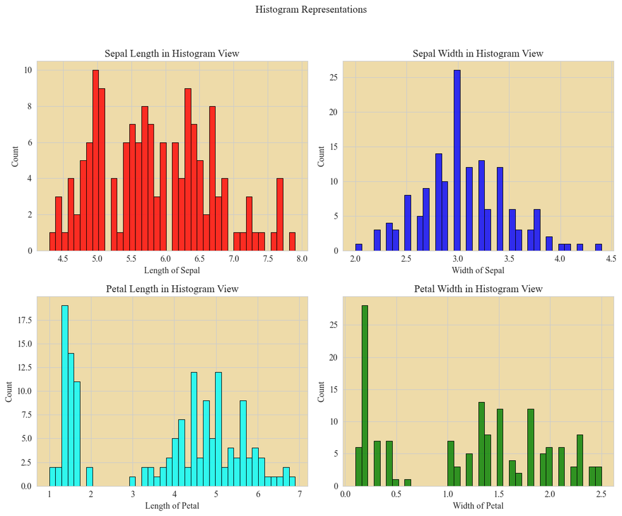

```python
# Histogram Representations
fig, axes = plt.subplots(2, 2, figsize=(12, 10))
fig.suptitle("Histogram Representations", fontsize=14)

# Sepal Length
sns.histplot(data=group2, x="SepalLengthCm", bins=40, color="red", edgecolor="black", ax=axes[0, 0], alpha=0.8)
axes[0, 0].set_title("Sepal Length in Histogram View")
axes[0, 0].set_xlabel("Length of Sepal")
axes[0, 0].set_ylabel("Count")
axes[0, 0].set_facecolor("#EEDbA9")

# Sepal Width
sns.histplot(data=group2, x="SepalWidthCm", bins=40, color="blue", edgecolor="black", ax=axes[0, 1], alpha=0.8)
axes[0, 1].set_title("Sepal Width in Histogram View")
axes[0, 1].set_xlabel("Width of Sepal")
axes[0, 1].set_ylabel("Count")
axes[0, 1].set_facecolor("#EEDbA9")

# Petal Length
sns.histplot(data=group2, x="PetalLengthCm", bins=40, color="cyan", edgecolor="black", ax=axes[1, 0], alpha=0.8)
axes[1, 0].set_title("Petal Length in Histogram View")
axes[1, 0].set_xlabel("Length of Petal")
axes[1, 0].set_ylabel("Count")
axes[1, 0].set_facecolor("#EEDbA9")

# Petal Width
sns.histplot(data=group2, x="PetalWidthCm", bins=40, color="green", edgecolor="black", ax=axes[1, 1], alpha=0.8)
axes[1, 1].set_title("Petal Width in Histogram View")
axes[1, 1].set_xlabel("Width of Petal")
axes[1, 1].set_ylabel("Count")
axes[1, 1].set_facecolor("#EEDbA9")

plt.tight_layout(rect=[0, 0, 1, 0.95])
plt.savefig("histogram_view.png")
```

The above graph shows the histogram representation of the data, illustrating the number of records with specific values. The relationship between the x and y axes represents the total number of records with the same values for each attribute present in the data.

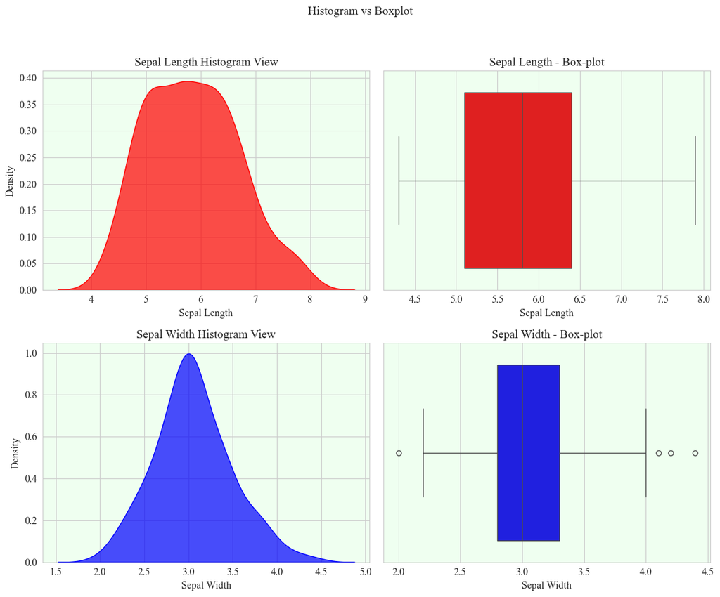

```python
# Histogram vs Boxplot (Part 1)
fig, axes = plt.subplots(2, 2, figsize=(12, 10))
fig.suptitle("Histogram vs Boxplot", fontsize=14)

# Sepal Length
sns.kdeplot(data=group2, x="SepalLengthCm", fill=True, color="red", alpha=0.7, ax=axes[0, 0], warn_singular=False)
axes[0, 0].set_title("Sepal Length Histogram View")
axes[0, 0].set_xlabel("Sepal Length")
axes[0, 0].set_facecolor("#EFFFF0")

sns.boxplot(data=group2, x="SepalLengthCm", color="red", ax=axes[0, 1])
axes[0, 1].set_title("Sepal Length - Box-plot")
axes[0, 1].set_xlabel("Sepal Length")
axes[0, 1].set_facecolor("#EFFFF0")

# Sepal Width
sns.kdeplot(data=group2, x="SepalWidthCm", fill=True, color="blue", alpha=0.7, ax=axes[1, 0], warn_singular=False)
axes[1, 0].set_title("Sepal Width Histogram View")
axes[1, 0].set_xlabel("Sepal Width")
axes[1, 0].set_facecolor("#EFFFF0")

sns.boxplot(data=group2, x="SepalWidthCm", color="blue", ax=axes[1, 1])
axes[1, 1].set_title("Sepal Width - Box-plot")
axes[1, 1].set_xlabel("Sepal Width")
axes[1, 1].set_facecolor("#EFFFF0")

plt.tight_layout(rect=[0, 0, 1, 0.95])
plt.savefig("histogram_vs_boxplot_1.png")
```

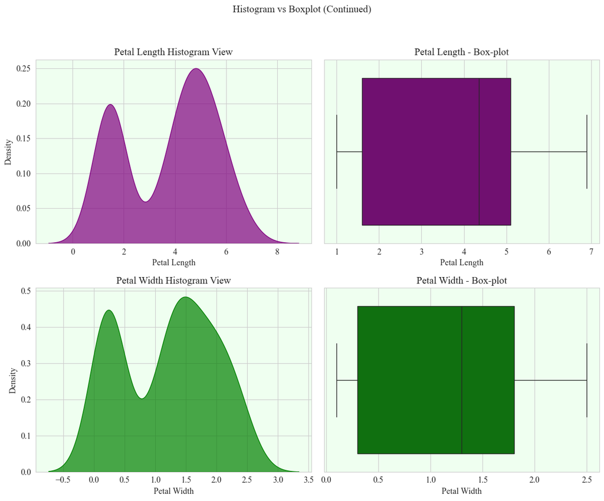

```python
# Histogram vs Boxplot (Part 2)
fig, axes = plt.subplots(2, 2, figsize=(12, 10))
fig.suptitle("Histogram vs Boxplot (Continued)", fontsize=14)

# Petal Length
sns.kdeplot(data=group2, x="PetalLengthCm", fill=True, color="purple", alpha=0.7, ax=axes[0, 0], warn_singular=False)
axes[0, 0].set_title("Petal Length Histogram View")
axes[0, 0].set_xlabel("Petal Length")
axes[0, 0].set_facecolor("#EFFFF0")

sns.boxplot(data=group2, x="PetalLengthCm", color="purple", ax=axes[0, 1])
axes[0, 1].set_title("Petal Length - Box-plot")
axes[0, 1].set_xlabel("Petal Length")
axes[0, 1].set_facecolor("#EFFFF0")

# Petal Width
sns.kdeplot(data=group2, x="PetalWidthCm", fill=True, color="green", alpha=0.7, ax=axes[1, 0], warn_singular=False)
axes[1, 0].set_title("Petal Width Histogram View")
axes[1, 0].set_xlabel("Petal Width")
axes[1, 0].set_facecolor("#EFFFF0")

sns.boxplot(data=group2, x="PetalWidthCm", color="green", ax=axes[1, 1])
axes[1, 1].set_title("Petal Width - Box-plot")
axes[1, 1].set_xlabel("Petal Width")
axes[1, 1].set_facecolor("#EFFFF0")

plt.tight_layout(rect=[0, 0, 1, 0.95])
plt.savefig("histogram_vs_boxplot_2.png")
```

The above representation shows the difference between histogram and box plot representations. In histograms, we see a wave created by connecting all the data points, whereas in box plots, all records are highlighted within a certain region.

### ii. Analysis on Species

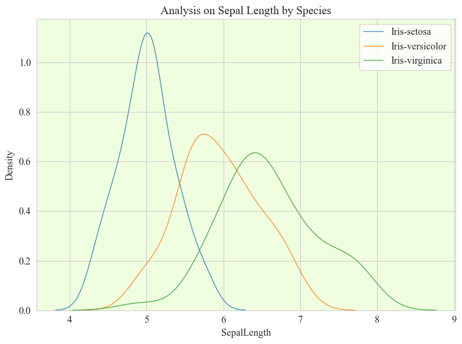

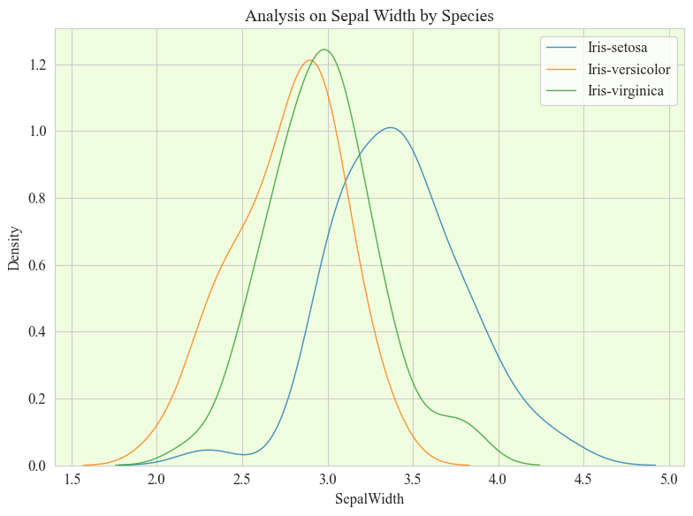

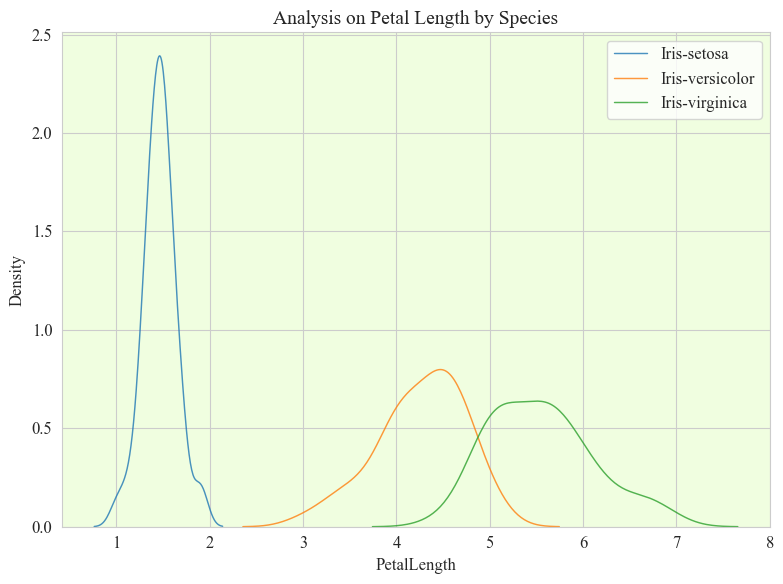

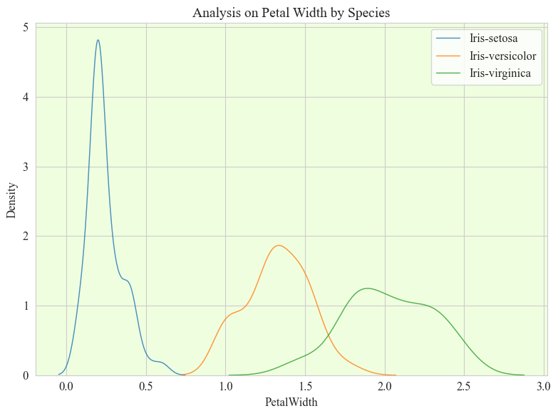

```python
# Analysis on Species (Density Plots)
for feature, title in [
    ("SepalLengthCm", "Analysis on Sepal Length by Species"),
    ("SepalWidthCm", "Analysis on Sepal Width by Species"),
    ("PetalLengthCm", "Analysis on Petal Length by Species"),
    ("PetalWidthCm", "Analysis on Petal Width by Species")
]:
    plt.figure(figsize=(8, 6))
    for species in group2["Species"].unique():
        sns.kdeplot(data=group2[group2["Species"] == species], x=feature, label=species, alpha=0.8, warn_singular=False)
    plt.title(title)
    plt.xlabel(feature.replace("Cm", ""))
    plt.legend()
    plt.gca().set_facecolor("#F0FEE0")
    plt.tight_layout()
    plt.savefig(f"density_{feature}.png")
```

The above graphs show the analysis of Sepal Length, Sepal Width, Petal Length, and Petal Width for each species in the data.

### iii. Analysis on Species with Ridgeline

```python
# Check variance to ensure data suitability for ridgeline plots
print(group2.groupby("Species").var())
```

```
                 SepalLengthCm  SepalWidthCm  PetalLengthCm  PetalWidthCm
Species
Iris-setosa           0.124249      0.145180       0.030106      0.011494
Iris-versicolor       0.266433      0.098469       0.220816      0.039106
Iris-virginica        0.404343      0.104004       0.304588      0.075433
```

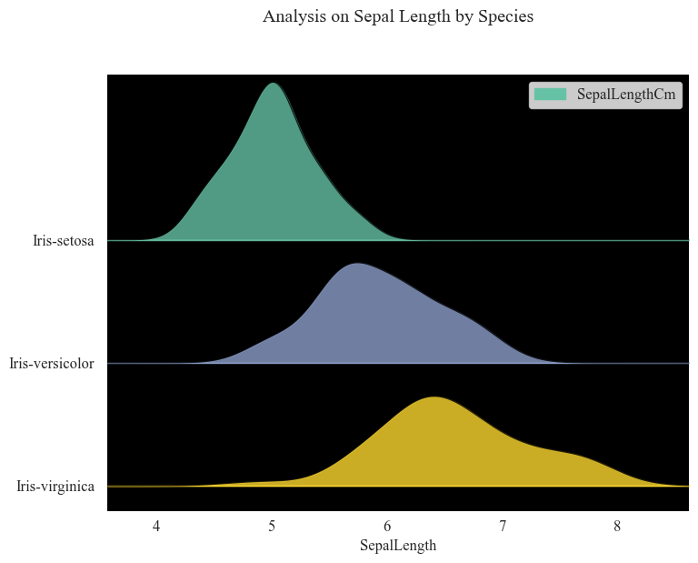

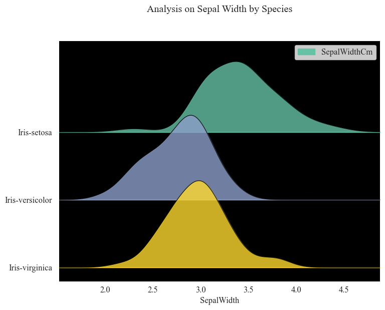

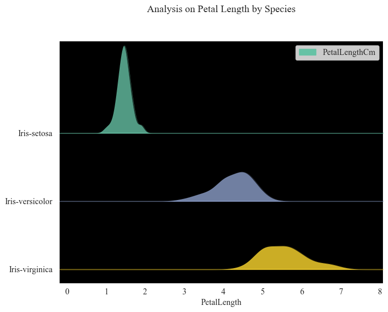

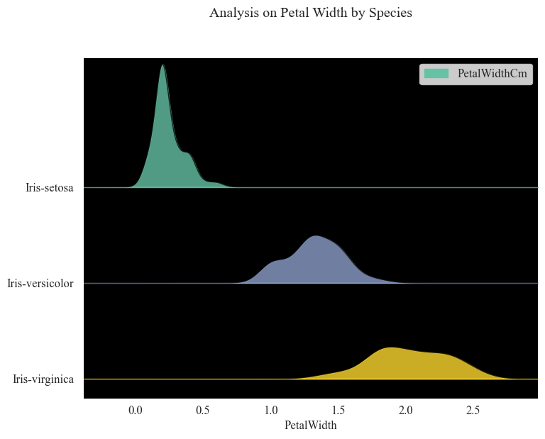

```python
# Ridgeline Plots using joypy
for feature, title, filename in [
    ("SepalLengthCm", "Analysis on Sepal Length by Species", "ridgeline_sepal_length.png"),
    ("SepalWidthCm", "Analysis on Sepal Width by Species", "ridgeline_sepal_width.png"),
    ("PetalLengthCm", "Analysis on Petal Length by Species", "ridgeline_petal_length.png"),
    ("PetalWidthCm", "Analysis on Petal Width by Species", "ridgeline_petal_width.png")
]:
    fig, axes = joypy.joyplot(group2, by="Species", column=feature, alpha=0.8, figsize=(8, 6), colormap=plt.cm.Set2, legend=True)
    plt.suptitle(title, y=1.02)
    plt.xlabel(feature.replace("Cm", ""))
    plt.gca().set_facecolor("#000000")
    plt.subplots_adjust(left=0.1, right=0.9, top=0.9, bottom=0.1)
    plt.savefig(filename, dpi=300)
```

Now we see the same analysis with ridgeline plots, where the values of each species are displayed as overlapping density plots, making it easier to compare distributions across species.

### iv. Additional Graph Representations (Line, Bar, Pie)

In this section, we add line graphs, bar graphs, and pie charts to provide further insights into the Iris dataset.

#### Line Graph: Average Measurements by Species

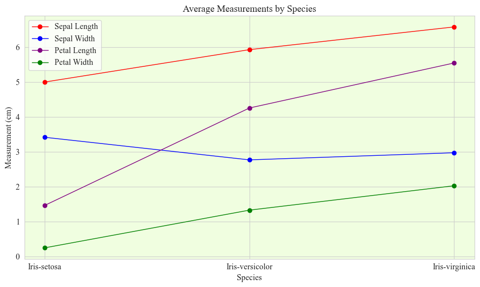

```python
# Line Graph: Average Measurements by Species
# Calculate the mean for each feature by species
mean_by_species = group2.groupby('Species').mean().reset_index()

plt.figure(figsize=(10, 6))
# Plot each feature as a line
plt.plot(mean_by_species['Species'], mean_by_species['SepalLengthCm'], marker='o', label='Sepal Length', color='red')
plt.plot(mean_by_species['Species'], mean_by_species['SepalWidthCm'], marker='o', label='Sepal Width', color='blue')
plt.plot(mean_by_species['Species'], mean_by_species['PetalLengthCm'], marker='o', label='Petal Length', color='purple')
plt.plot(mean_by_species['Species'], mean_by_species['PetalWidthCm'], marker='o', label='Petal Width', color='green')

plt.title('Average Measurements by Species')
plt.xlabel('Species')
plt.ylabel('Measurement (cm)')
plt.legend()
plt.gca().set_facecolor("#F0FEE0")
plt.tight_layout()
plt.savefig("line_graph_measurements.png")
```

The line graph above shows the average measurements (Sepal Length, Sepal Width, Petal Length, and Petal Width) for each species in the Iris dataset. Each line represents a different measurement, with markers indicating the mean value for each species. This visualization helps compare how the average measurements vary across species, highlighting differences such as Iris-setosa having smaller petal measurements compared to Iris-virginica.

#### Bar Graph: Count of Each Species

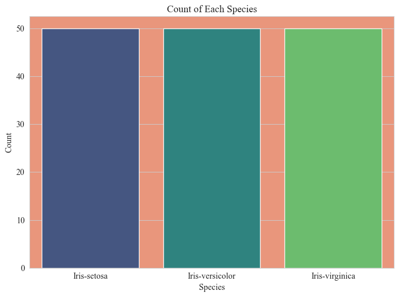

```python
# Bar Graph: Count of Each Species
species_counts = group2['Species'].value_counts()

plt.figure(figsize=(8, 6))
sns.barplot(x=species_counts.index, y=species_counts.values, hue=species_counts.index, palette='viridis', legend=False)
plt.title('Count of Each Species')
plt.xlabel('Species')
plt.ylabel('Count')
plt.gca().set_facecolor("#E9967C")
plt.tight_layout()
plt.savefig("bar_graph_species_count.png")
```

The bar graph above displays the count of each species in the Iris dataset. Each bar represents a species, and the height of the bar indicates the number of records for that species. This visualization confirms that the dataset is balanced, with an equal number of records for each species (50 records each for Iris-setosa, Iris-versicolor, and Iris-virginica).

#### Pie Chart: Proportion of Each Species

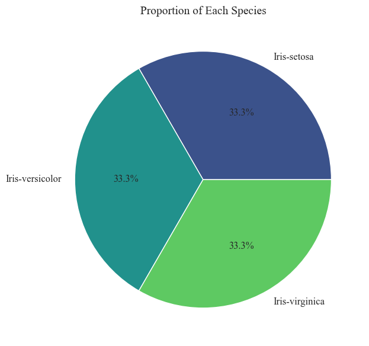

```python
# Pie Chart: Proportion of Each Species
species_counts = group2['Species'].value_counts()

plt.figure(figsize=(8, 6))
plt.pie(species_counts.values, labels=species_counts.index, autopct='%1.1f%%', colors=sns.color_palette('viridis', len(species_counts)))
plt.title('Proportion of Each Species')
plt.gca().set_facecolor("#F5FFFA")
plt.tight_layout()
plt.savefig("pie_chart_species_proportion.png")
```

The pie chart above illustrates the proportion of each species in the Iris dataset as a percentage. Each slice of the pie represents a species, with the percentage labeled on the slice. This visualization further confirms the balanced nature of the dataset, with each species contributing approximately 33.3% to the total, indicating an even distribution of the three species.

### v. Analysis on Boxplot View

#### Violin View

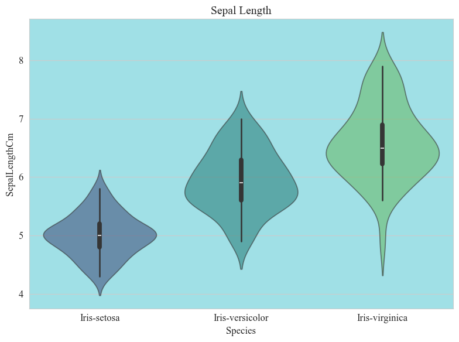

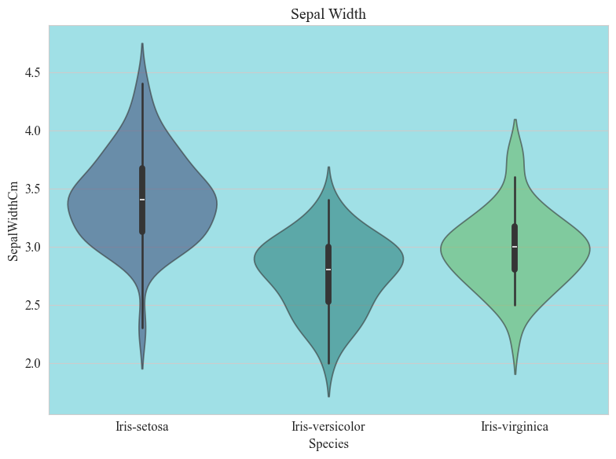

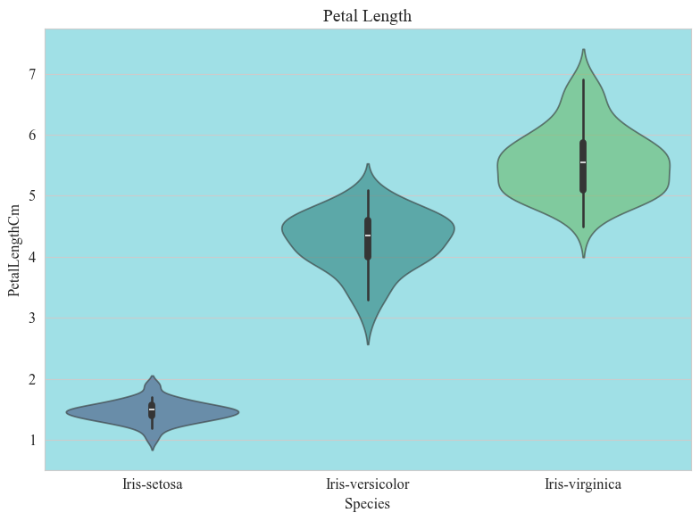

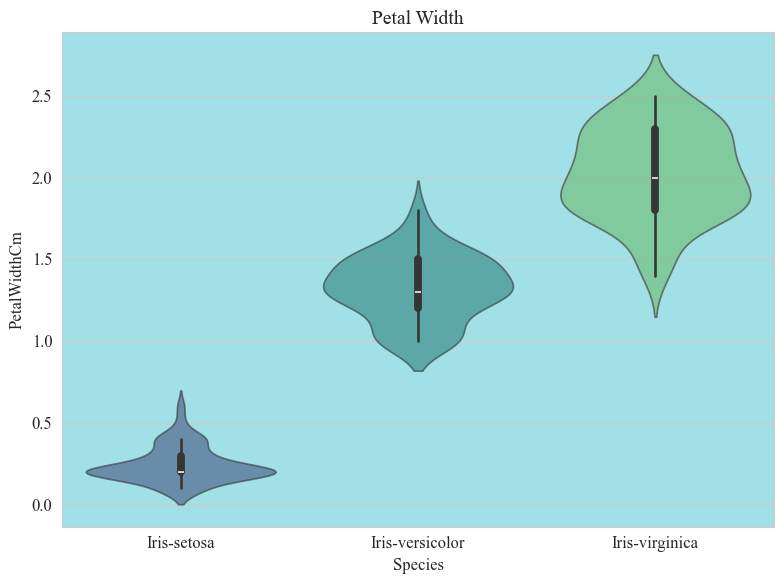

```python
# Violin Plots
for feature, title in [
    ("SepalLengthCm", "Sepal Length"),
    ("SepalWidthCm", "Sepal Width"),
    ("PetalLengthCm", "Petal Length"),
    ("PetalWidthCm", "Petal Width")
]:
    plt.figure(figsize=(8, 6))
    sns.violinplot(data=group2, x="Species", y=feature, hue="Species", palette="viridis", alpha=0.6, legend=False)
    plt.title(title)
    plt.gca().set_facecolor("#A0E0E6")
    plt.tight_layout()
    plt.savefig(f"violin_{feature}.png")
```

```python
# Violin with Box Plots
for feature, title in [
    ("SepalLengthCm", "Sepal Length"),
    ("SepalWidthCm", "Sepal Width"),
    ("PetalLengthCm", "Petal Length"),
    ("PetalWidthCm", "Petal Width")
]:
    plt.figure(figsize=(8, 6))
    sns.violinplot(data=group2, x="Species", y=feature, hue="Species", palette="viridis", alpha=0.6, legend=False)
    sns.boxplot(data=group2, x="Species", y=feature, hue="Species", palette="viridis", width=0.1, boxprops=dict(facecolor="white", alpha=0.2), legend=False)
    plt.title(title)
    plt.gca().set_facecolor("#E9967C")
    plt.tight_layout()
    plt.savefig(f"violin_box_{feature}.png")
```

[output not shown]

#### Box Plot View

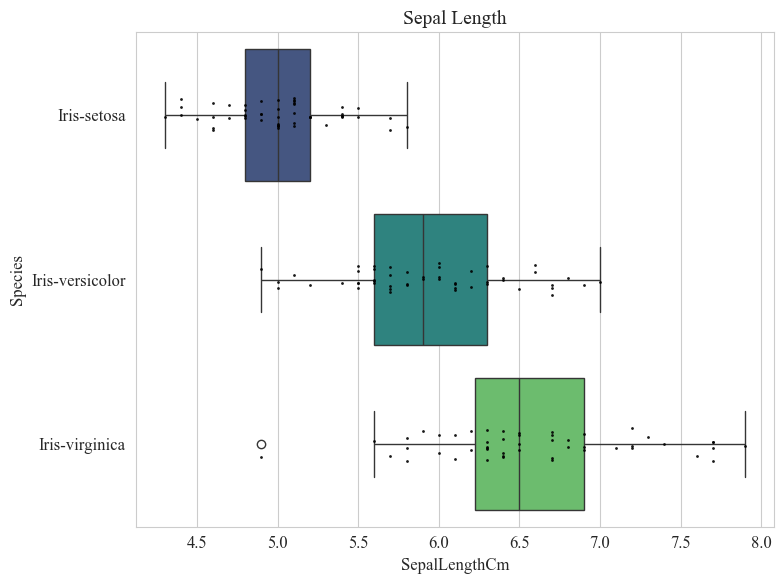

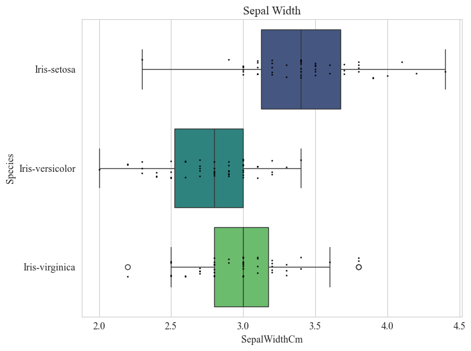

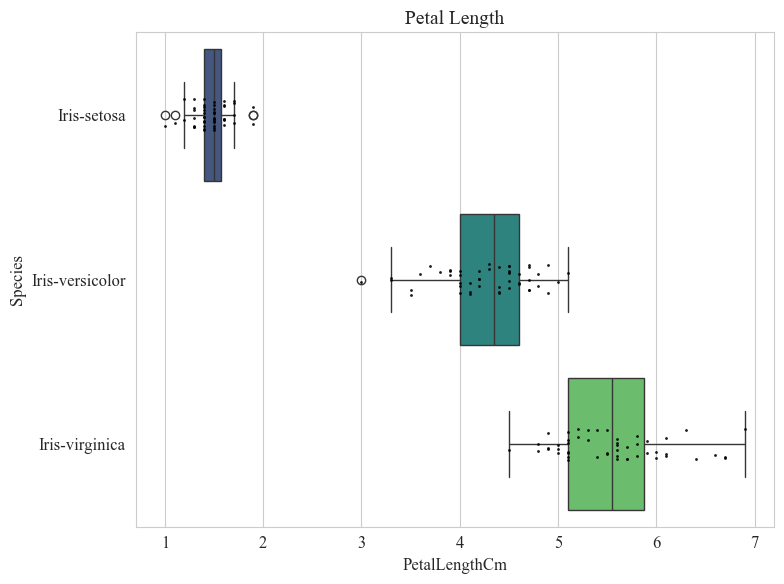

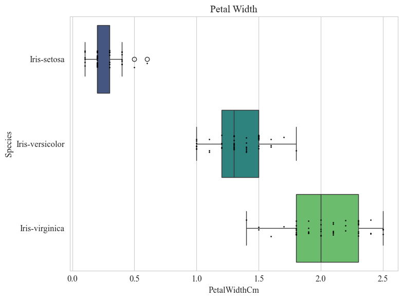

```python
# Box Plots with Jitter
for feature, title in [
    ("SepalLengthCm", "Sepal Length"),
    ("SepalWidthCm", "Sepal Width"),
    ("PetalLengthCm", "Petal Length"),
    ("PetalWidthCm", "Petal Width")
]:
    plt.figure(figsize=(8, 6))
    sns.boxplot(data=group2, x=feature, y="Species", hue="Species", palette="viridis", legend=False)
    sns.stripplot(data=group2, x=feature, y="Species", color="black", size=2, alpha=0.9)
    plt.title(title)
    plt.tight_layout()
    plt.savefig(f"box_jitter_{feature}.png")
```

### vi. Analysis on Scatter Plot

#### Analysis on Length and Width of Species

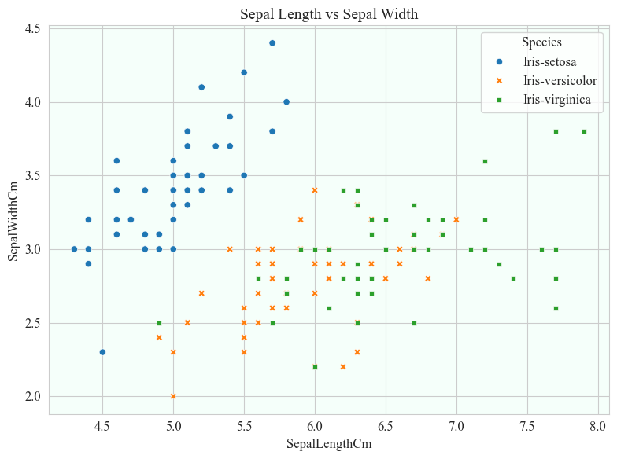

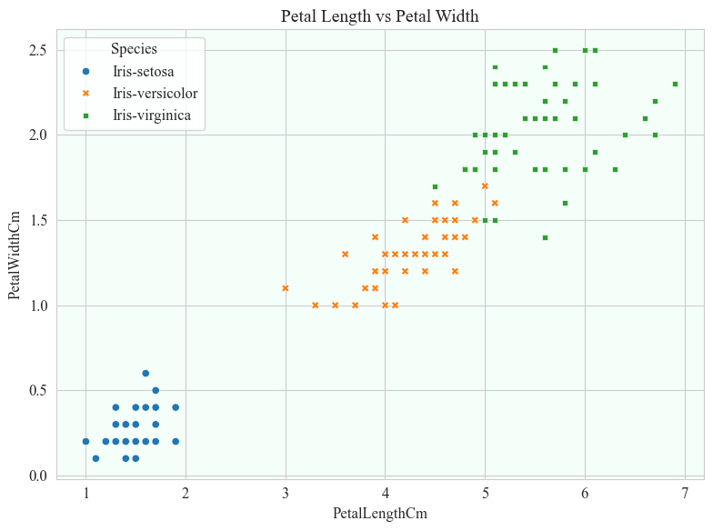

```python
# Scatter Plots
# Sepal Length vs Width
plt.figure(figsize=(8, 6))
sns.scatterplot(data=group2, x="SepalLengthCm", y="SepalWidthCm", hue="Species", style="Species", sizes=(2, 2))
plt.title("Sepal Length vs Sepal Width")
plt.gca().set_facecolor("#F5FFFA")
plt.tight_layout()
plt.savefig("scatter_sepal.png")

# Petal Length vs Width
plt.figure(figsize=(8, 6))
sns.scatterplot(data=group2, x="PetalLengthCm", y="PetalWidthCm", hue="Species", style="Species", sizes=(2, 2))
plt.title("Petal Length vs Petal Width")
plt.gca().set_facecolor("#F5FFFA")
plt.tight_layout()
plt.savefig("scatter_petal.png")
```

#### Analysis on Sepal Length and Width of Species

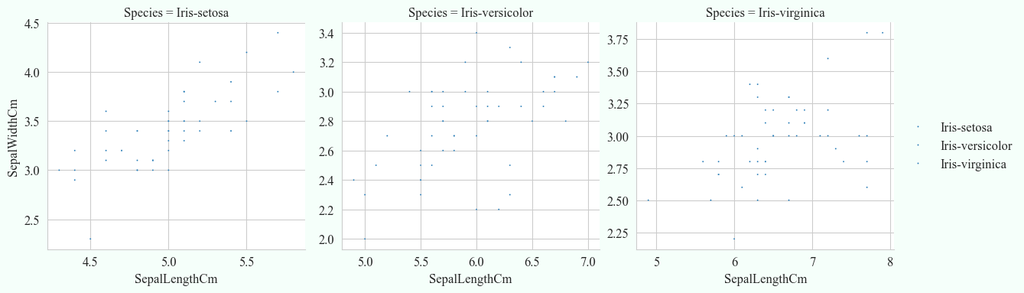

```python
# Faceted Scatter for Sepal
g = sns.FacetGrid(group2, col="Species", col_wrap=3, height=4, sharex=False, sharey=False)
g.map(sns.scatterplot, "SepalLengthCm", "SepalWidthCm", "Species", "Species", sizes=(2, 2))
g.add_legend()
g.fig.set_facecolor("#F5FFFA")
plt.savefig("faceted_scatter_sepal.png")
```

#### Analysis on Petal Length and Width of Species

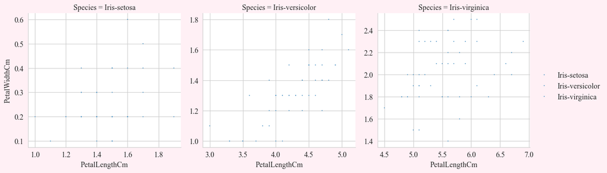

```python
# Faceted Scatter for Petal
g = sns.FacetGrid(group2, col="Species", col_wrap=3, height=4, sharex=False, sharey=False)
g.map(sns.scatterplot, "PetalLengthCm", "PetalWidthCm", "Species", "Species", sizes=(2, 2))
g.add_legend()
g.fig.set_facecolor("#FFF0F5")
plt.savefig("faceted_scatter_petal.png")
```

### vii. Analysis on Correlation Graphs

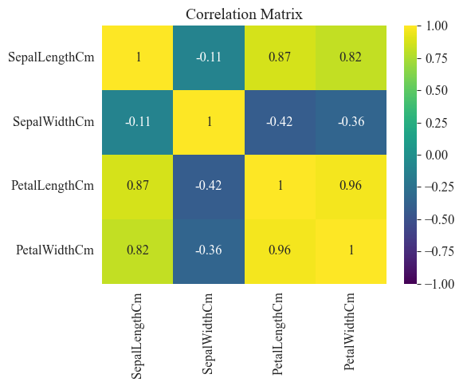

```python
# Correlation Matrix
corr = group2[["SepalLengthCm", "SepalWidthCm", "PetalLengthCm", "PetalWidthCm"]].corr()
plt.figure(figsize=(6, 5))
sns.heatmap(corr, annot=True, cmap="viridis", vmin=-1, vmax=1)
plt.title("Correlation Matrix")
plt.gca().set_facecolor("#F5FFFA")
plt.tight_layout()
plt.savefig("correlation_matrix.png")
```

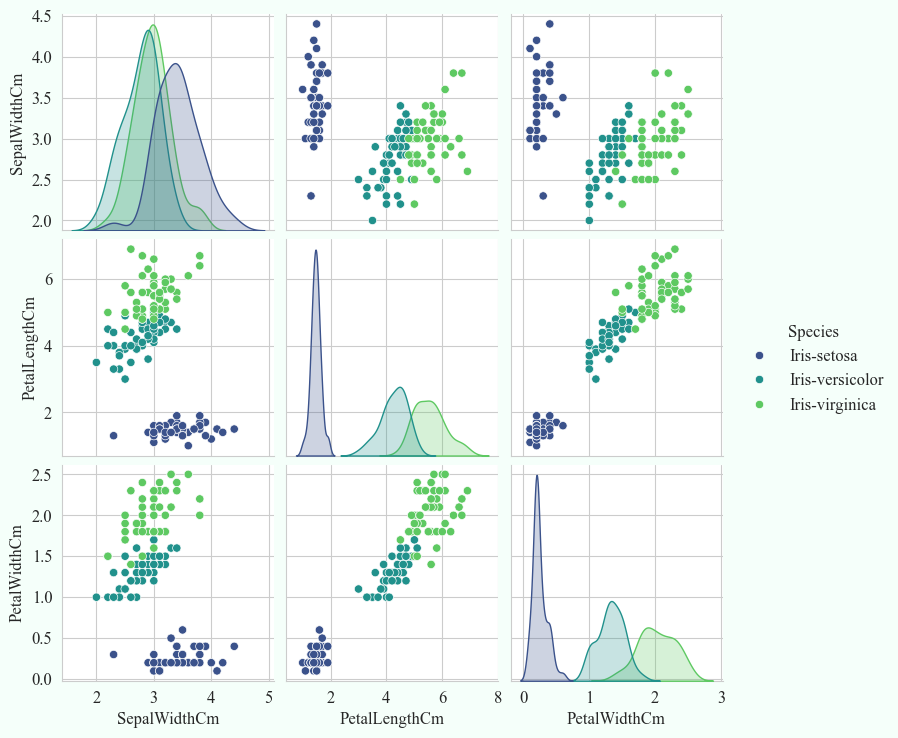

```python
# Pairplot for selected columns
sns.pairplot(group2, vars=["SepalWidthCm", "PetalLengthCm", "PetalWidthCm"], hue="Species", palette="viridis")
plt.gcf().set_facecolor("#F5FFFA")
plt.savefig("pairplot.png")
```

## Generating HTML Output

To generate an HTML file containing all explanations, code, and plots, run the following command in your terminal after executing this notebook:

```
jupyter nbconvert --to html iris_visualization.ipynb
```

This will create `iris_visualization.html` in the same directory, which includes all content displayed above.